# Data Visualization R Project 1

Monica Huang and Rachel Arthur

September 15, 2015

After creating a repository on GitHubt to manage our code, we then created a dataframe from the titanic data. Using the SQL statement:

```
SELECT * FROM titanic
```

```r
# Change the USER and PASS below to be your UTEid
df <- data.frame(fromJSON(getURL(URLencode('129.152.144.84:5001/rest/native/?query="select * from titanic where sex is not null"'),httpheader=c(DB='jdbc:oracle:thin:@129.152.144.84:1521/PDBF15DV.usuniversi01134.oraclecloud.internal', USER='cs329e_mh42375', PASS='orcl_mh42375', MODE='native_mode', MODEL='model', returnDimensions = 'False', returnFor = 'JSON'), verbose = TRUE), ))
```

**7. Display a subset and summary of the Titanic data frame.**

Subsets:

```
##   PCLASS                                                NAME    FARE
## 1      3                             Braund, Mr. Owen Harris  7.2500
## 2      1 Cumings, Mrs. John Bradley (Florence Briggs Thayer) 71.2833
## 3      3                              Heikkinen, Miss. Laina  7.9250
## 4      1        Futrelle, Mrs. Jacques Heath (Lily May Peel) 53.1000
## 5      3                            Allen, Mr. William Henry  8.0500
## 6      3                                    Moran, Mr. James  8.4583
```

Summary:

```
##   PASSENGERID       SURVIVED          PCLASS
##  Min.   :  1.0   Min.   :0.0000   Min.   :1.000
##  1st Qu.:222.8   1st Qu.:0.0000   1st Qu.:2.000
##  Median :445.5   Median :0.0000   Median :3.000
##  Mean   :445.6   Mean   :0.3834   Mean   :2.309
##  3rd Qu.:668.2   3rd Qu.:1.0000   3rd Qu.:3.000
##  Max.   :891.0   Max.   :1.0000   Max.   :3.000
##
##                                     NAME         SEX           AGE
##  Johansson, Mr. Gustaf Joel           :  2   female:314   null   :177
##  Abbing, Mr. Anthony                  :  1   male  :578   24     : 30
##  Abbott, Mr. Rossmore Edward          :  1                22     : 27
##  Abbott, Mrs. Stanton (Rosa Hunt)     :  1                18     : 26
##  Abelson, Mr. Samuel                  :  1                19     : 25
##  Abelson, Mrs. Samuel (Hannah Wizosky):  1                28     : 25
##  (Other)                              :885                (Other):582
##      SIBSP            PARCH             TICKET         FARE
##  Min.   :0.0000   Min.   :0.0000   1601    :  7   Min.   :  0.000
##  1st Qu.:0.0000   1st Qu.:0.0000   347082  :  7   1st Qu.:  7.918
##  Median :0.0000   Median :0.0000   CA. 2343:  7   Median : 14.454
##  Mean   :0.5224   Mean   :0.3812   3101295 :  6   Mean   : 32.178
##  3rd Qu.:1.0000   3rd Qu.:0.0000   347088  :  6   3rd Qu.: 31.000
##  Max.   :8.0000   Max.   :6.0000   CA 2144 :  6   Max.   :512.329
##                                    (Other) :853
##          CABIN     EMBARKED
##  null       :688   C   :168
##  B96 B98    :  4   Q   : 77
##  C23 C25 C27:  4   S   :645
##  G6         :  4   null:  2
##  C22 C26    :  3
##  D          :  3
##  (Other)    :186
```

### Plot #2

**SQL Statement:**

```
SELECT * FROM titanic WHERE sex is not null
```

```
ggplot() +
  coord_cartesian() +
  scale_x_continuous() +
  scale_y_continuous() +
  labs(title='Titanic') +
  labs(x="Age", y="Fare") +
  layer(data=df,
        mapping=aes(x=as.numeric(AGE), y=as.numeric(as.character(FARE)), color=SEX),
        stat="identity",
        stat_params=list(),
        geom="point",
        geom_params=list(),
        position=position_jitter(width=0.3, height=0)
  )
```

This plot visualizes the ages of all passengers versus their ticket fares. They are color coded by sex. A larger number of women paid fares over $200.

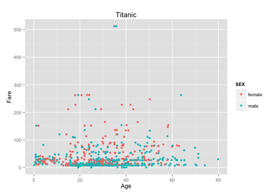

### Plot #3

**SQL Statement:**

```
SELECT * FROM titanic WHERE sex is not null
```

```
ggplot() +
  coord_cartesian() +
  scale_x_discrete() +
  scale_y_continuous() +
  labs(title='Titanic') +
  labs(x="Survived", y=paste("Fare")) +
  layer(data=df,
        mapping=aes(x=SEX, y=as.numeric(as.character(FARE)), color=as.character(SURVIVED)),
        stat="identity",
        stat_params=list(),
        geom="point",
        geom_params=list(),
        position=position_jitter(width=0.3, height=0)
  )
```

This plot visualizes the surviving males and females on the Titanic and their ticket fares. More women surivived the crash, which is not surprising because they were the ones allowed onto the life boats first, along with children.

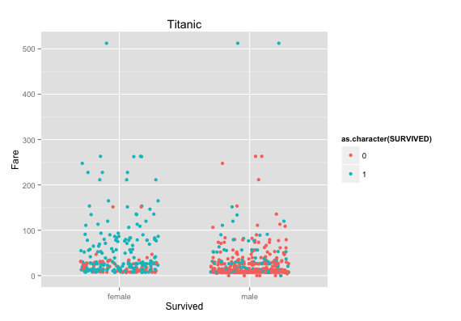

### Plot #4

**SQL Statement:**

```
SELECT * FROM titanic WHERE where sex is not null"
```

```
ggplot() +
  coord_cartesian() +
  scale_x_discrete() +
  scale_y_continuous() +
  facet_grid(PCLASS~SURVIVED, labeller=label_both) +
  labs(title='Titanic') +
  labs(x="Survived", y=paste("Fare")) +
  layer(data=df,
        mapping=aes(x=SEX, y=as.numeric(as.character(FARE)), color=SEX),
        stat="identity",
        stat_params=list(),
        geom="point",
        geom_params=list(),
        position=position_jitter(width=0.3, height=0)
  )
```

This plot shows whether passengers survived based on their ticket fare, sex, and class. Passengers in classes 1 and 2 were more likely to survive if they were females. Passengers in class 3 were less likely to survive than passengers in classes 1 and 2, whether they were male or female.

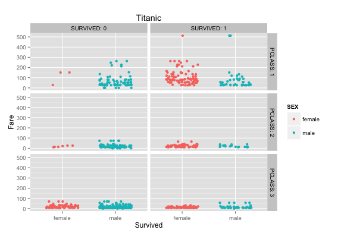

### Plot #5

**SQL Statement:**

```
SELECT * FROM titanic WHERE age <= 10"
```

```
ggplot() +
  coord_cartesian() +
  scale_x_discrete() +
  scale_y_continuous() +
  facet_grid(PCLASS~SURVIVED, labeller=label_both) +
  labs(title='Titanic where age <= 10') +
  labs(x="Survived", y=paste("Fare")) +
  layer(data=df,
        mapping=aes(x=SEX, y=as.numeric(as.character(FARE)), color=SEX),
        stat="identity",
        stat_params=list(),
        geom="point",
        geom_params=list(),
        position=position_jitter(width=0.3, height=0)
  )
```

This plot shows the survival of passengers under the age of ten based on class, sex, and ticket fare. There is no clear difference between the survival of children in class 3, but class 2 children all survived.

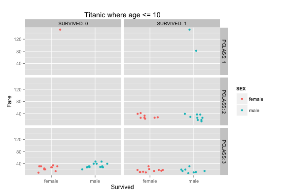